# 第12回 テキストマイニング（形態素解析・単語頻度・Bag of Words・単語埋め込み）

経済データとプログラミングII

第12回

テキストマイニング

言葉を数にする

経済データとプログラミングII

第12回 — Topic01

形態素解析

日本語はどこで区切る？

## 第12回の道のり

1

区切る

実習：実行 準備と白書の読み込み

実習：実行 語の区切り

2

数える

実習：実行 3 段の数え上げ

3

表にする

実習：実行 日報の表

実習：実行 白書の表の形

4

近さを測る

実習：実行 埋め込みの読み込み

実習：実行 近い語の検索

いまココ。日本語の文を、語に区切る

## 前の回の振り返り

前の回のポイント

Q: 売上 1 本の記録を、どうやって予測する表にしたか

- **窓切り**：過去の何期分かを横に並べ、次の 1 期を $y$ にした
- **機械に入れたもの**：景気の指数も GDP も、ずっと数だった

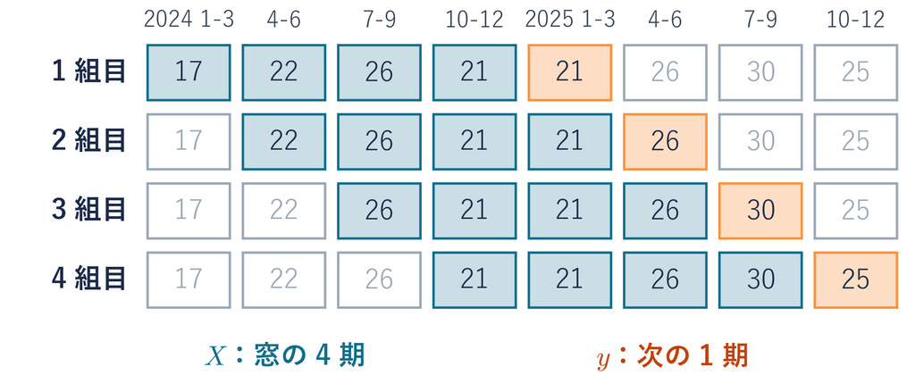

今日は、数ではない情報を機械に入れる

## このトピックで学ぶこと

- **ここまで**：数の表なら、`fit` に渡して機械で予測できた
- **でも**：ゼミのアンケートの自由記述が 200 件。全部は読めない  
  経済の情報も多くは文章（白書・お店の日報）
- **問い**：文章から「何の話が多いか」を、数で知れないか
- **進め方**：前半はお店の日報 3 行、後半で経済財政白書

アンケートの「はい 12・いいえ 8」と同じく、言葉も数える  
数える前に「何を 1 つと数えるか」を決める。それが区切る

## 準備と白書の読み込みのセル

```python
!pip install -q sudachipy sudachidict-core==20260428
import numpy as np
import pandas as pd
from collections import Counter
from sudachipy import Dictionary, SplitMode
from sklearn.feature_extraction.text import CountVectorizer
```

```python
BASE = "ここに manaba の URL を貼る"
wp = pd.read_csv(BASE + "whitepaper_text.csv")
print(len(wp))
```

**先に書き換える**：`BASE` の中を、manaba の URL の最後の `/` まで  
（例 `"https://…/data/"`）

**道具**：日本語を区切る道具 `sudachipy`  
区切り方が変わらないよう、辞書の版を固定

**出力**：`348` は経済財政白書の段落の数（1 行が 1 段落）

⏸ PAUSE 動画を止めてセルを 2 つ実行。`348` が出たら再生に戻る

## よくある失敗 文字列のままの学習

✕ 日報の文章をそのまま表の列に入れて、前と同じく fit に渡す

```
LinearRegression().fit(pd.DataFrame({"日報": ["売上が増えた。", "売上は増えていない。
", "客足が減った。"]}), [1, 0, -1])
```

`ValueError: could not convert string to float: '売上が増えた。'`

**エラーの意味**：「売上が増えた。」を数（小数）に直せなかった

**わけ**：機械が受け取れるのは数だけ。文字は、そのままでは入らない

文章を、先に数に直してから渡す

## お店の日報 3 行

数える前に：何を 1 個と数えるか（どこで区切るか）を決める

|  | 日報 |
| --- | --- |
| A | 売上が増えた。 |
| B | 売上は増えていない。 |
| C | 客足が減った。 |

**英語**：*sales went up* は、空白で 3 つの語に切れる

**日本語**：「売上が増えた。」は続いていて、どこで切るかが書いていない

**1 文字ずつ**：売上の「上」も上昇の「上」も、同じ 1 個に数えてしまう  
（白書では「上」が 1,348 回）

文字ではなく、意味のまとまり（語）で区切りたい

## 日報 3 行の区切り

[figure not shown]

5 ＋ 7 ＋ 5 ＝ 17 個に区切れた。色は語の種類（品詞）の札

## ◼ 形態素解析

**形態素解析：文を語に区切り、1 つずつ品詞の札を付ける**

用語

**形態素解析**：文を語（意味のまとまり）に区切り、1 つずつ品詞を付けること

**トークン**：区切った 1 つ 1 つ（日報 3 行なら 17 個）

**品詞**：語の種類（名詞・動詞・助詞・助動詞・記号…）

**区切る道具**：SudachiPy。語と品詞を載せた辞書と照らして、文を前から区切る

**品詞の札**：次に、どの語を残すかを選ぶのに使う

## 残す語と落とす語

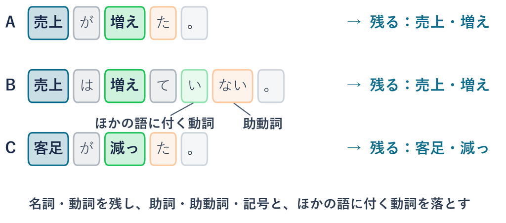

**内容語**：何の話か（話題）を運ぶ語（名詞・動詞・形容詞・副詞）。これだけを残す

**落とす語**：助詞・助動詞・記号・数字と、ほかの語に付いて働く「いる」「する」などの動詞

「ない」は話題ではなく向き（増えた／増えていない）を運ぶが、ここで落ちる。  
困ることは表にしたときに見る

## ◼ 正規化形

用語

**正規化形**：書き方や活用のゆれを、辞書の 1 つの形にそろえたもの

| 区切った形 | 増え・増える | 売上・売り上げ | 減っ |
| --- | --- | --- | --- |
| 正規化形 | 増える | 売り上げ | 減る |

そろえないと、同じ「増える」が別々の語として数えられる

A [売り上げ 増える]・B [売り上げ 増える]・C  
[客足 減る]。内容語 6 個（4 種類）

## 白書の冒頭段落の区切り

今度は経済財政白書の冒頭段落で、同じ手順を  
内閣府が毎年出す、日本経済を分析した報告書。第 1・2 章の 348 段落を使う

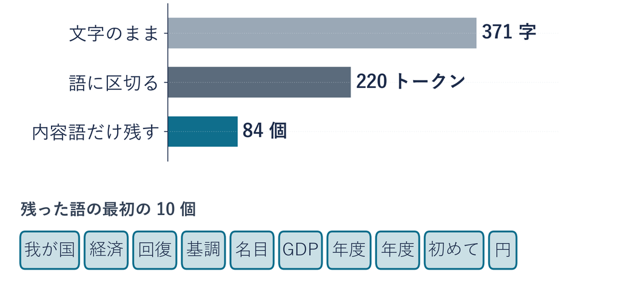

371 字が内容語 84 個に。我が国・経済・回復…と、何の話かが見え始める

## 語の区切りのセル

```python
tok = Dictionary().create()
def wakachi(text):
    words = []
    for m in tok.tokenize(text, SplitMode.C):
        pos = m.part_of_speech()
        if pos[0] in ["名詞", "動詞", "形容詞", "副詞"] and pos[1] not in ["非自立可能", "数詞"]:
            words.append(m.normalized_form())
    return words
text = wp["text"][0]
print(len(text), len(tok.tokenize(text, SplitMode.C)), len(wakachi(text)))
print(wakachi(text)[:10])
```

| 行 | 部品 | 渡すもの | できるもの |
| --- | --- | --- | --- |
| 1 | **道具を用意** | 辞書 | 区切る道具 `tok` |
| 2-4 | **1 つずつ区切る** | 文 `text` | トークン `m` |
| 5-8 | **内容語だけ残す** | `pos[0]` 品詞・`pos[1]` 細かい種類 | 正規化形の語 |
| 9-11 | **使う・見る** | 冒頭段落 | `371 220 84` と 10 語 |

⏸ PAUSE 動画を止めてセルを実行。`371 220 84` が出たら再生に戻る

## ✋ たしかめ 区切りの数

たしかめ

「日本の経済成長が注目されている。」は、いくつに区切れるか

**ⓐ** 3 **ⓑ** 6 **ⓒ** 11

句点「。」も 1 個と数える

⏸ PAUSE 動画を止めて 1 分。選んだら再生に戻る

## たしかめの答え

答えは **ⓒ 11**

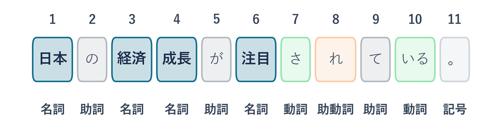

**辞書の切り方**：経済成長は 経済＋成長、注目されている は 注目＋さ＋れ＋て＋いる

**「さ」**：「する」の形。ほかの語に付いて働く動詞なので落ちる

残るのは 日本・経済・成長・注目 の 4 語

## まとめ

- 文字列は、そのままでは `fit` に入らない
- 形態素解析：文を語に区切り、1 つずつ品詞の札を付ける
- 内容語だけ残し、正規化形でそろえる
- 日報 3 行は 17 トークン → 内容語 6 個。白書の段落は 371 字 → 84 個

文は、語に区切れた  
残った問い：区切った語を数えると、何が見えるか。これを次のトピックで見る

経済データとプログラミングII

第12回 — Topic02

単語頻度とストップワード

いちばん多い言葉は何？

## 第12回の道のり

1

区切る

実習：実行 準備と白書の読み込み

実習：実行 語の区切り

2

数える

実習：実行 3 段の数え上げ

3

表にする

実習：実行 日報の表

実習：実行 白書の表の形

4

近さを測る

実習：実行 埋め込みの読み込み

実習：実行 近い語の検索

いまココ。区切った語を数える

## このトピックで学ぶこと

- **ここまで**：文を、語に区切れた
- **でも**：アンケートの自由記述 200 件も、白書の 348 段落も、全部は読めない
- **問い**：何の話が多いかを、数で知りたい
- **進め方**：前半はお店の日報 3 行、後半で白書 348 段落

そこで、区切った語を数える（アンケートの集計と同じ）

## ◼ 頻度

用語

**頻度**：その語が出た回数

[figure not shown]

何もしないと 1 位は句点「。」  
内容語だけ数えると、何の話かが見える

## ✋ たしかめ 白書の上位の語

たしかめ

白書 348 段落を何もせずに数えると、上位 5 つに入る語は

**ⓐ** 経済 **ⓑ** 賃金 **ⓒ** の

⏸ PAUSE 動画を止めて 1 分。選んだら再生に戻る

## 何もしない数え方の上位

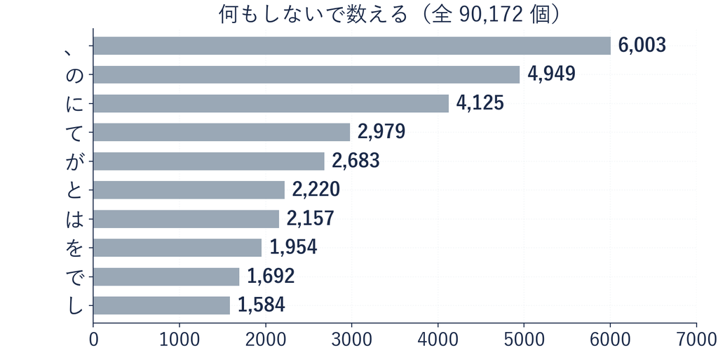

答えは **ⓒ の**（1 位は読点「、」6,003）

上位 10 は、それだけでは話題を運ばない語ばかり。何の話かが、1 つも見えない

## 品詞で絞った数え方の上位

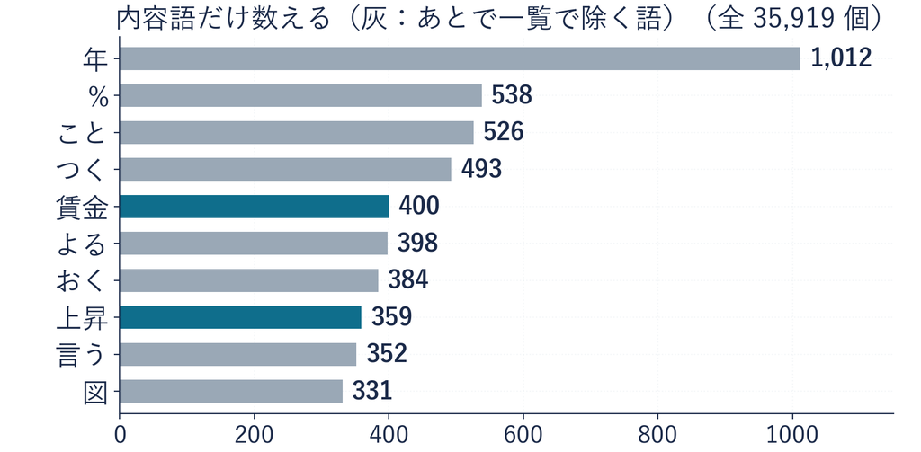

賃金・上昇が出てきた。でも年・%・こと・つく（灰）も上位にいる  
「%」は名詞あつかい、「つく」は動詞なので、品詞では落ちない

## よくある失敗 品詞だけの絞り込み

✕ 品詞で絞れば、話題の語だけが残る

名詞・動詞を残したので、残ったのは中身のある語だと思いたくなる

| 残った語 | もとの言い回し |
| --- | --- |
| つく（493 回） | 〜について |
| よる | 〜による |
| おく | 〜における |
| 言う | 〜という |

動詞の形をした言い回しは、品詞では落ちない。  
一覧に書き出して、一覧の語は数えない

## ◼ ストップワード

**ストップワード：話題を運ばないので、数えない語**

用語

**品詞で落とす語**：助詞・助動詞・記号（区切るときに `wakachi` が落とす）

**一覧で落とす語**：品詞では落ちない語を、除く語の一覧 `STOP` に書いて除く

| 除く語の一覧 `STOP`（13 語） |  |
| --- | --- |
| 数や図に付く語 | 年・%・図・月 |
| どんな話にも付く言い回し | こと・つく・よる・おく・言う・ 程度・以降・対する・物 |

賃金のような話題の語を入れると、話題そのものが消える。  
入れるのは、どんな話にも付く語だけ

## 一覧で除いた数え方の上位

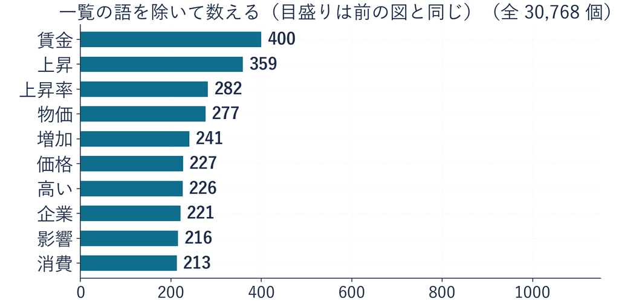

賃金 400 が 1 位。物価・価格・消費と、白書の話題が並んだ  
多い＝よく書かれた話題、まで。大事かどうかは中身を読んで決める

## 3 段の数え上げのセル

```python
raw = [m.surface() for t in wp["text"] for m in tok.tokenize(t, SplitMode.C)]
words = [w for t in wp["text"] for w in wakachi(t)]
STOP = ["年", "%", "こと", "つく", "よる", "おく", "言う", "図", "月", "程度", "以降", "対する", "物"]
print(Counter(raw).most_common(10))
print(Counter(words).most_common(10))
print(Counter([w for w in words if w not in STOP]).most_common(10))
```

| 行 | 部品 | 渡すもの | できるもの |
| --- | --- | --- | --- |
| 1 | **何もしない** `surface()` | 白書の全段落 | 区切ったままの語 `raw` |
| 2 | **内容語だけ** `wakachi` | 白書の全段落 | 正規化形の語 `words` |
| 3 | **除く語の一覧** `STOP` | 13 語 | 数えない語 |
| 4-6 | **数える** `Counter` | 3 つの並び | 上位 10 の (語, 回数) |

出力は 3 行。各行の最初の (語, 回数) が 1 位：`('、', 6003)`・`('年', 1012)`・`('賃金', 400)`

⏸ PAUSE 動画を止めてセルを実行。3 行の 1 位を見たら再生に戻る

## ✋ たしかめ 一覧で除く語

たしかめ

除く語の一覧 `STOP` に入れるべきなのは、どれか

**ⓐ** 賃金 **ⓑ** つく **ⓒ** 物価

⏸ PAUSE 動画を止めて 1 分。選んだら再生に戻る

## たしかめの答え

答えは **ⓑ つく**

**つく**：「〜について」の一部（493 回）。話題を運ばない

**賃金・物価**：白書の話題そのもの。除くと話題が消える

**授業の外で**：アンケートの自由記述も、同じ手順で「何が多く書かれたか」が出る

## まとめ

- 頻度：その語が出た回数
- 何もしないと、上位は「、」「の」
- 品詞で絞っても、言い回しの「つく」が残る
- ストップワード：品詞で落とす語と、一覧で落とす語
- 一覧で除くと、白書の 1 位は賃金 400

数えると、話題が見えた。でも白書全体の数では、  
日報の A と B が同じ話かは分からない  
残った問い：文 1 つ 1 つを比べるには、どうするか。  
これを次のトピックで見る

経済データとプログラミングII

第12回 — Topic03

Bag of Words

文章を数の表にするとは？

## 第12回の道のり

1

区切る

実習：実行 準備と白書の読み込み

実習：実行 語の区切り

2

数える

実習：実行 3 段の数え上げ

3

表にする

実習：実行 日報の表

実習：実行 白書の表の形

4

近さを測る

実習：実行 埋め込みの読み込み

実習：実行 近い語の検索

いまココ。文を、数の表の 1 行にする

## このトピックで学ぶこと

- **ここまで**：白書全体で、どの語が多いかを数えた
- **でも**：どの段落が賃金の話で、どの段落が物価の話かを比べたい  
  しかも機械は数しか受け取らない（文字のままでは止まった）
- **問い**：1 つの文を、1 本の数の並びにできないか
- **進め方**：前半はお店の日報 3 行、後半で白書 348 段落

そこで、白書全体を数えた手順を 1 文ずつやって、行に並べる  
行が 1 件・列が数の表は、前の回まで fit に渡してきた形と同じ

## 日報 3 行の表

行：文、列：残った語（内容語を辞書の形にそろえた・前のトピックの手順）。  
マスはその文にその語が出た回数

[figure not shown]

列の並びは、機械が文字コードの順に決める（五十音順ではない・ノートの出力と同じ）

## ◼ Bag of Words

**Bag of Words：文を、語ごとの回数を並べた表の 1 行にする**

用語

**Bag of Words**：語の並びを捨てて、各語の回数だけを並べた数の並び  
（Bag は袋の意味）

**語彙**：表の列に並ぶ語の一覧（日報なら 4 語）

**文書-単語行列**：行が文書（日報なら 1 文、白書なら 1 段落）・列が語の表

日報 3 行の表は、3 行 × 4 列の文書-単語行列（行列＝数の表のこと）

## ★ 「ない」を残した表

日報 3 行の表では、A と B が同じ行 [1 1 0 0]。意味は逆なのに  
原因は、最初のトピックで内容語だけを残したとき「ない」を落としたこと

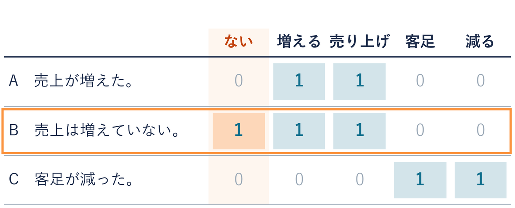

「ない」を残すと、B は別の行になる

## 語を残すか落とすかの選択

落とす

話題が見えやすい  
白書の話題をつかみたいとき

残す

否定が残る  
口コミが良いか悪いかを  
知りたいとき

何を残すかは分析する人の選択。何を知りたいかで決める

## 語の並びの消失

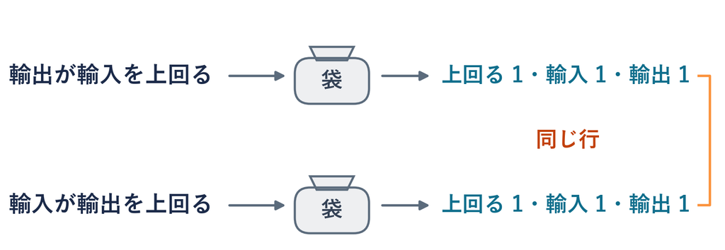

語を全部残しても、どちらが上回ったかは消える。そのかわり、  
長さの違う文も同じ列数の行にそろう  
前の回は、並び順を 1 つずつ順に読む機械（RNN）を見た。  
Bag of Words は、その並びを捨てる

## 日報の表のセル

```python
shop = ["売上が増えた。", "売上は増えていない。", "客足が減った。"]
cv = CountVectorizer(token_pattern=r"(?u)\S+")
X = cv.fit_transform([" ".join(wakachi(s)) for s in shop])
print(cv.get_feature_names_out())
print(X.toarray())
```

```python
def wakachi_nai(text):
    return wakachi(text) + [m.surface() for m in tok.tokenize(text, SplitMode.C) if m.surface() == "ない"]
X2 = cv.fit_transform([" ".join(wakachi_nai(s)) for s in shop])
print(cv.get_feature_names_out())
print(X2.toarray())
```

**道具**：`CountVectorizer` は語を数えて表にする。fit は列にする語を決める

**書き方**：語を空白でつなぎ（`" ".join`）、空白ごとに 1 語と数える

**出力**：上は A・B・C の表、下は「ない」を残した表（中は読まなくてよい）

⏸ PAUSE 動画を止めてセルを 2 つ実行。表の A と B を見たら再生に戻る

## ✋ たしかめ 4 行目の日報

たしかめ

D「売上は減っていない。」を  
「ない」を落とした日報の表に足すと

**ⓐ** A と同じ行 **ⓑ** C と同じ行 **ⓒ** どれとも違う行

⏸ PAUSE 動画を止めて 1 分。選んだら再生に戻る

## たしかめの答え

答えは **ⓒ どれとも違う行**

|  | 増える | 売り上げ | 客足 | 減る |
| --- | --- | --- | --- | --- |
| A | 1 | 1 | 0 | 0 |
| C | 0 | 0 | 1 | 1 |
| D | 0 | **1** | 0 | **1** |

B は A と同じ行なので省いた

表の上では、D は「売上が減った」と同じ形。意味は逆

## ✋ たしかめ 白書の表の列の数

たしかめ

今度は白書 348 段落で。表にすると、列は何本か

**ⓐ** 約 300 **ⓑ** 約 3,000 **ⓒ** 約 30,000

列は、どこかの段落に 1 回でも出た内容語の種類の数

⏸ PAUSE 動画を止めて 1 分。選んだら再生に戻る

## ★ 白書の文書-単語行列

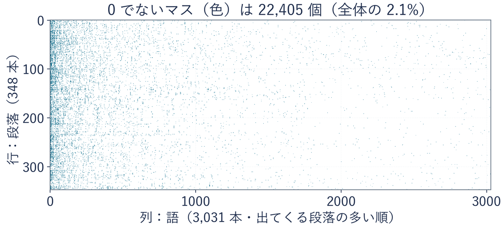

答えは **ⓑ**。348 行 × 3,031 列（横は見やすいように並べ替えた）

**疎**：ほとんどのマスが 0 であること。1 行 3,031 個のうち、0 でないのは平均およそ 64 個

## 白書の表の形のセル

```python
docs = [" ".join(wakachi(t)) for t in wp["text"]]
X3 = CountVectorizer(token_pattern=r"(?u)\S+").fit_transform(docs)
print(X3.shape)
```

| 行 | 部品 | 渡すもの | できるもの |
| --- | --- | --- | --- |
| 1 | **段落を語の並びに** `wakachi` | 348 段落 | 語を空白でつないだ文 |
| 2 | **表にする** `fit_transform` | `docs` | 文書-単語行列 `X3` |
| 3 | **形を見る** `.shape` | `X3` | `(348, 3031)` |

`token_pattern` を付けないと、円・人など 1 文字の語を中心に 142 語が黙って消える

⏸ PAUSE 動画を止めてセルを実行。`(348, 3031)` で再生に戻る

## 表で測れない語の近さ

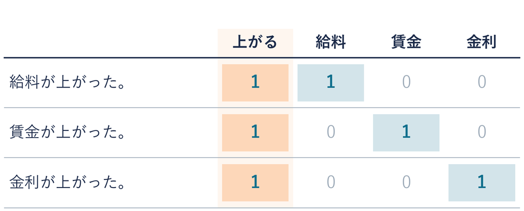

給料と賃金は別々の列。どの 2 文も、共通の列は「上がる」の 1 本だけ  
人なら給料と賃金はほぼ同じ話と分かる。でも表の上では、給料の文と賃金の文は、  
金利の文と同じだけしか似ていない

## まとめ

- Bag of Words：文を、語ごとの回数を並べた表の 1 行にする
- 文書-単語行列：行が文書・列が語。白書は 348 × 3,031 で疎
- 行が 1 件・列が数の表なので、前の回までの道具に渡せる
- 語の並びと、落とした「ない」は表から消える

文は、数の行になった  
残った問い：表では語どうしが無関係。  
語の近さを数で表せないか。これを次のトピックで見る

経済データとプログラミングII

第12回 — Topic04

単語埋め込み

近い意味は、近い場所に置ける？

## 第12回の道のり

1

区切る

実習：実行 準備と白書の読み込み

実習：実行 語の区切り

2

数える

実習：実行 3 段の数え上げ

3

表にする

実習：実行 日報の表

実習：実行 白書の表の形

4

近さを測る

実習：実行 埋め込みの読み込み

実習：実行 近い語の検索

いまココ。語を座標に置いて、近さを測る

## このトピックで学ぶこと

- **ここまで**：文を、表の 1 行にできた
- **でも**：表のままだと「給料」で探して「賃金」の記事は見つからない  
  給料・賃金・金利の 3 文は、どの組も共通の列が「上がる」だけ
- **問い**：語どうしの近さを、数で表せないか
- **進め方**：前半は手で置いた 4 語、後半で借りた本物の表

前に、A さんをバイト 1 日・サークル 1 日の 2 つの数で、平面の点にした  
語も、全部の語に共通の少しの数で表せば、点になる

## 4 語の点と矢印

横：お金の話らしさ、縦：動物の話らしさ。説明のために手で置いた座標

[figure not shown]

お金の話によく出る語は、お金の目盛りが大きい。  
だから同じ場面の 2 語は、ほぼ同じ向き

## ◼ 単語埋め込み

**単語埋め込み：語を、全部の語に共通の少しの数で点にする**

用語

**単語埋め込み**：語を、同じ場面で使う語ほど近い向きに来る  
数の並び（座標）にしたもの

表（Bag of Words）

語 1 つに列 1 本（白書なら 3,031 本）  
給料の列と賃金の列は別々

単語埋め込み

全部の語が同じ本数の列を使う  
（手の例は 2 本、借りた表は 768 本）

## ◼ コサイン類似度

給料 (5, 1) のような語の数の並びを、原点から伸びる矢印と見る  
**ベクトル**：向きと長さを持つ矢印

[figure not shown]

**コサイン類似度：なす角が小さいほど似ている、大きいほど似ていない**

## 近さの計算

式

$$\text{近さ} = \cos\theta = (\vec{a} \cdot \vec{b}) \div (|\vec{a}| \times |\vec{b}|)$$

なす角は、**ベクトルの内積**（$\vec{a} \cdot \vec{b}$）という計算を使って測る

$\vec{a}$, $\vec{b}$：比べる 2 語のベクトル（給料なら (5, 1)）。上の矢印はベクトルの印

$\vec{a} \cdot \vec{b}$：内積。横どうし、縦どうしを掛けて足す

$|\vec{a}|$, $|\vec{b}|$：ベクトルの長さ（原点から点まで）

$\theta$：2 本のベクトルのなす角

**給料と賃金**：近さ ≈ 1.00（なす角が小さい）

**給料と犬**：近さ ≈ 0.35（なす角が大きい）

同じ向きで 1、直角で 0、反対向きで −1。長さで割るので、向きだけが残る

## 埋め込みの座標の決め方

疑問：この座標は、だれが決めたのか（お金の話らしさに、だれが点を付けるのか）

[figure not shown]

**表との違い**：表は 1 文の中だけ。埋め込みは何万文ぶんの周りを合わせて決まる

**名前**：本物の数には「お金の話らしさ」のような名前は付いていない

知らない語に出会ったとき、  
人も前後の語から意味を推し量る。それを数でやったもの

## 借りた埋め込みの表

**出どころ**：文章を読む AI が、最初に語を数に置き換える表  
（主に、隠した語を予測する練習で決まった）

**大きさ**：元の表は 32,768 行（「〜る」のような語のかけらを含む）  
そのうち語の形の 23,974 語を配った。1 語に 768 個の数

**近さの式**：平面には描けないが、式は同じ（掛けて足すのが 768 回になるだけ）

今度はこの借りた表で、同じ近さを測る

## 表と埋め込みの近さ

表：「犬」「猫」「金利」の 1 語だけの文を 3 行にした表で、行どうしの近さを測る

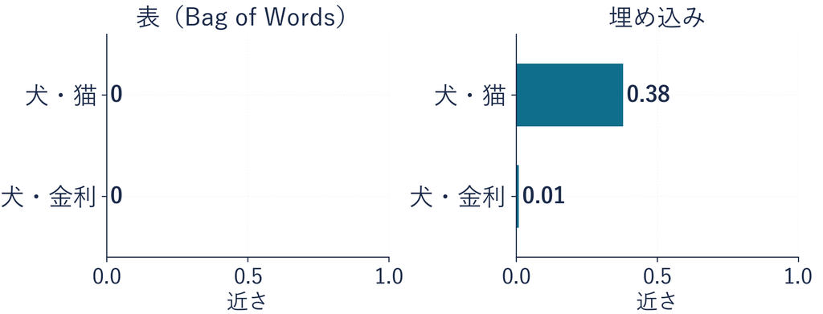

表では語ごとに自分だけの列（別々の向き）。違う語どうしは直角で、近さ 0  
埋め込みでは 犬・猫 0.38、犬・金利 0.01。0.01 と比べれば、0.38 はずっと近い

## 賃金とバイトに近い語

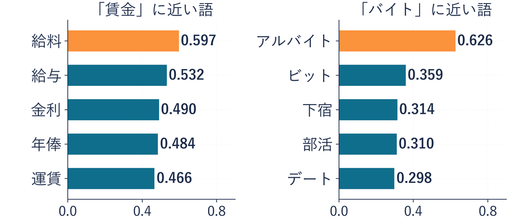

賃金に近い順の 1 位は給料、バイトの 1 位はアルバイト。  
数の大きさより、順位で読む  
ビットは、コンピュータの「バイト」の意味が混ざったもの  
（同じ書き方の語は、点が 1 つしかない）

## 12 語の意味の地図

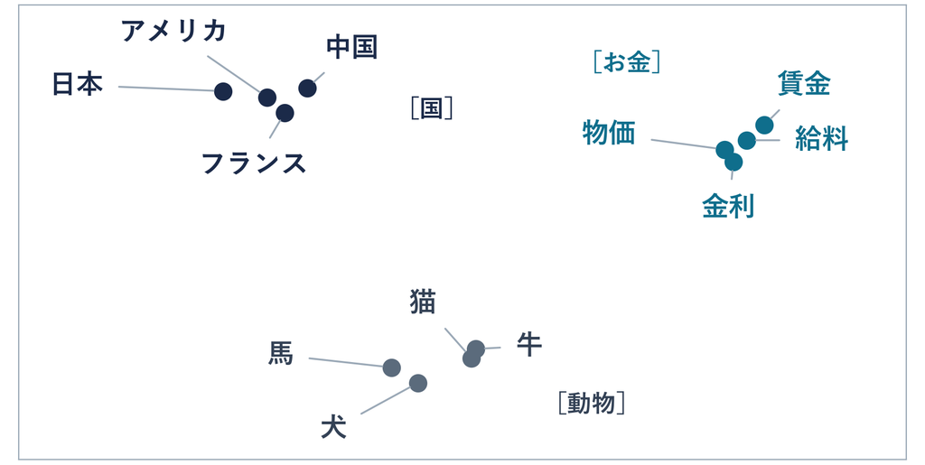

動物・お金・国の 3 つのかたまりに分かれる  
768 個の数を 2 つに縮めて描いた地図。縦と横に名前は無い

## 埋め込みの読み込みのセル

```python
import urllib.request
if BASE:
    urllib.request.urlretrieve(BASE + "word_vectors.npz", "word_vectors.npz")
z = np.load("word_vectors.npz")
vocab = z["words"].tolist()
V = z["vectors"].astype("float32")
row = {w: i for i, w in enumerate(vocab)}
print(V.shape)
```

```python
def cos(a, b):
    x, y = V[row[a]], V[row[b]]
    return float(x @ y / (np.linalg.norm(x) * np.linalg.norm(y)))
print(round(cos("犬", "猫"), 2), round(cos("犬", "金利"), 2))
```

上：1-3 行で、表のファイルを manaba の URL から取る  
（手元から上げた人は BASE を空のまま）  
4-7 行で、語の一覧 `vocab` と数の表 `V` を読む。`(23974, 768)` と出る  
下：`cos` は掛けて足して（`@`）、長さ（`norm`）で割る  
「近さの計算」のページの式そのまま。`0.38 0.01` と出る

## 近い語の検索のセル

```python
norms = np.linalg.norm(V, axis=1)
def most_similar(w, k=5):
    x = V[row[w]]
    s = V @ x / (norms * np.linalg.norm(x))
    top = [i for i in np.argsort(-s) if vocab[i] != w][:k]
    return [(vocab[i], round(float(s[i]), 3)) for i in top]
print(most_similar("賃金"))
```

| 行 | 部品 | 渡すもの | できるもの |
| --- | --- | --- | --- |
| 1 | **長さ** `norm` | 23,974 語の数 | 各語の長さ |
| 2-4 | **全部の語との近さ** | 語 `w` | 近さの並び `s` |
| 5-6 | **上位を選ぶ** `argsort` | `s` | 近い 5 語と近さ |
| 7 | **見る** | 「賃金」 | 給料 0.597 が 1 位 |

⏸ PAUSE 動画を止めて、前のページの 2 つとこのセル（計 3 つ）  
を実行。給料が 1 位なら再生に戻る

## ✋ たしかめ 好調に近い語

たしかめ

借りた表で「好調」にいちばん近い語は、どれか

**ⓐ** 順調 **ⓑ** 不振 **ⓒ** 好評

⏸ PAUSE 動画を止めて 1 分。選んだら再生に戻る

## ★ 好調にいちばん近い語

答えは **ⓑ 不振**

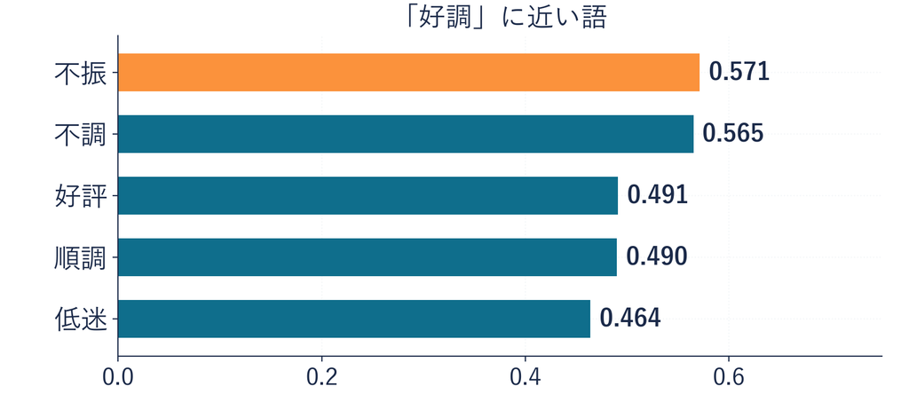

近さが測っているのは、意味が同じかより、同じ場面で使われるか

## ★ 同じ場面で使う語

**単語埋め込み：反対の意味でも、同じ場面で使う語は近い**

**好調**：「**業績**が好調な取引先からは、  
年度末までの改修工事などの依頼が増えている。」

**不振**：「今年は特に**業績**不振となっているという  
話を聞く機会が増えた。」

内閣府『景気ウォッチャー調査』（お店や会社の人に景気の実感を聞く調査）のコメント（2025 年 12 月・7 月）。  
表を作った文章とは別の、同じ場面の例

どちらも業績を語る同じ場所に来る。反対の意味でも、  
反対向きにはならず、同じ向きに寄る  
同じ意味の語（給料・賃金）も、反対の語（好調・不振）も、同じ場面に出るので近い

## デモ：言葉を数にする実験室

タブ

①区切る → ②数える → ③表にする → ④近さを測る。  
近さは 2 本の矢印の向きのそろい方（最大 1）

- **何を見るか**：選んだ語に近い 5 語と、その近さ。反対の意味の語が上位に来るか
- **図の意味**：棒は選んだ語に近い 5 語と近さ。地図は、  
  選べる 8 語とそれぞれにいちばん近い語（合わせて 16 語）を、  
  768 個の数を 2 つに縮めて描いたもの
- **操作**：語のボタン 8 つと、見方の「棒」「地図」、戻す

ミッション 反対の意味なのに近い組を、もう 1 つ探す

※ 次のスライドへ進むときは、デモの枠の外を一度クリックしてから ← → キーを押す

[interactive chart not shown]

## まとめ

- 単語埋め込み：語を、全部の語に共通の少しの数で点にする
- コサイン類似度：向きのそろい方で測る近さ
- 座標は周りの語で決まる。反対の意味でも同じ場面の語は近い
- 授業の外で：近さを使う検索なら、「給料」で「賃金」の記事も出る

残った問い：この表では「高い」は、価格が高いでも山が高いでも同じ 1 点のまま  
前の回は時系列で次の値を予測した。言葉でも、前の語から次の語を予測できる  
そのとき前の語のどれを重く見るかを、読むたびに変える。この仕組みは、あとで見る

## 第 12 回のまとめ

**区切る**：形態素解析で、文を語に区切り、品詞の札を付ける

**数える**：ストップワードを除くと、白書の話題（賃金 400）が見える

**表にする**：Bag of Words で、文が数の行になる  
並びと、落とした否定は消える

**近さを測る**：単語埋め込みとコサイン類似度で、賃金の隣は給料

言葉は、区切って数えれば数の表になる  
語を座標に置けば、意味の近さまで数で測れる